[figure not shown]

# Cleaning Checks & Crap

## – “We pass your cleaning checks so you don’t have to!”

## What We Do

We take care of your apartment cleaning checks for you. Whether it’s scrubbing the bathroom, vacuuming the carpet, or wiping down counters—we do it all so you don’t get fined or fail your check. Our professional team ensures your space meets all inspection requirements while you focus on what matters most to you.

## How It Works

Booking with us is simple and stress-free. Just schedule an appointment online or by phone, provide your address and preferred time, and our experienced team will take care of the rest. All appointments must be booked at least **1 day in advance** to ensure proper scheduling and preparation.

On the day of your cleaning, we ask that **at least one roommate is present** during the appointment. This ensures a smooth handoff, allows access to the apartment, and provides mutual protection against any potential disputes or false claims.

We bring all necessary cleaning supplies and ensure your space is thoroughly cleaned and **inspection-ready** according to typical student housing standards.

**Customer Satisfaction Guarantee:** If our cleaning does not pass inspection, we will provide a **full refund**, including reimbursement for any cleaning-related fees or fines you incur as a result. We stand behind the quality of our work.

Our mission is to help you pass your cleaning checks with zero hassle. Fast, affordable, and fully guaranteed.

## Pricing

**Individual Services:**  
• Room: $35  
• Bathroom: $25  
• Kitchen: $30  
• Living Room: $30  
• Deep-Cleaning Fee (if requested or required): +$30  
• Early Booking Discount (10+ days in advance): -20%

**Combo Packages:**  
• Room + Bathroom: $55 (save $5)  
• Kitchen + Living Room: $55 (save $5)  
• Full Apartment (Room + Bathroom + Kitchen + Living Room): $110 (save $10)

**Roommate & Group Discounts:**  
• 2 Rooms cleaned: $65 (save $5)  
• 3+ Rooms cleaned: $30 per room (save $15+ total)

Book early and save! Let us handle the mess so you can stress less.

## Reviews & Results

Here is a before and after for the work we did for Carlos!

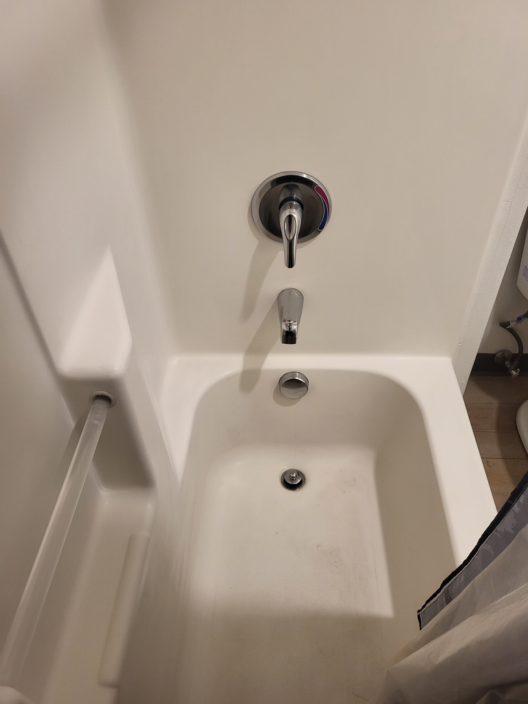

AFTER

[figure not shown]

BEFORE

“Everything was awesome! I was worried about it not being perfect but the apartment really was white glove clean when I walked in to grab my stuff. 5/5!”

— Carlos

## Book Now

To book an appointment for us to come to your apartment to complete your cleaning check, please either contact us through email or by filling out the form below. Thank you!

[Book Now](https://docs.google.com/forms/d/e/1FAIpQLSfWYVfLmmCOcZTjRhamiC-byDUJAnuUORYGc9BIxGVTzmEnqg/viewform?usp=header) or contact us through our email: cleaningchecksandcrap@gmail.com